# Two Sample Tests

# Two sample tests

When performing two sample tests, the first step is to examine the relationship between the samples.

Are they **independent** or **paired**?

Paired (clones) examples:

The same books sold at two different shops The same students being marked in two different schools The same people before and after some drug treatment

Independent:

Two different sets of books sold at two different shops School results from different students at two different schools Holiday let prices at two different locations

## Independent samples

```r
library(tidyverse)
library(infer)
```

```r
nice <- read_csv("data/nice.csv")
algarve <- read_csv("data/algarve.csv")
```

> We have two samples of prices (in £s) for 2-bedroom, 14-day holiday apartment lets in Nice and the Algarve. We would like to know whether the mean price of lets in the Algarve is significantly higher than the mean price of comparable lets in Nice.

### Define test and significance level

H0: price in algarve is the same as (or less than) the price in Nice H0: mean(algarve) - mean(nice) <= 0 HA: price in Algarve is higher than the price in Nice HA: mean(algarve) - mean(nice) > 0

significance level = 0.05

### Calculate sample statistic

```r
let_prices <- bind_rows(list(
  "algarve" = algarve,
  "nice" = nice
), .id = "location") %>%
  select(location, price)
```

```r
observed_stat <- let_prices %>%
  group_by(location) %>%
  summarise(mean_price = mean(price)) %>%
  pivot_wider(names_from = location, values_from = mean_price) %>%
  mutate(price_diff = algarve - nice)
```

### Generate null distribution and visualise

```r
null_distribution <- let_prices %>%
  specify(price ~ location) %>%               # does price depend on location?
  hypothesise(null = "independence") %>%      # H0 there is no dependence
  generate(reps = 1000, type = "permute") %>% # permute to shuffle labels
  calculate(stat = "diff in means",
            order = c("algarve", "nice"))     # algarve - nice
```

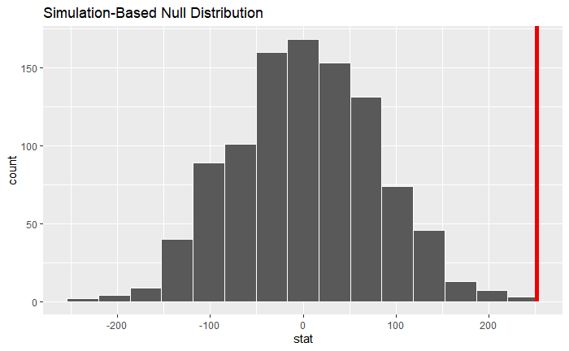

```r
null_distribution %>%
  visualise() +
  shade_p_value(
    obs_stat = observed_stat$price_diff,
    direction = "greater"
  )
```

### Calculate p value

```r
p_value <- null_distribution %>%
  get_p_value(
    obs_stat = observed_stat$price_diff,
    direction = "greater"
  ) %>%
  pull()
format.pval(p_value)
```

```
[1] "< 2.22e-16"
```

p < 0.0001

### Conclude

Our p value for our observed stat is lower than our significance level. We may reject H0 in favour of HA: Holiday let prices are more expensive in the Algarve than in comparable lets in Nice

# Practice

> On average, is the price of 2-bedroom, 14-day holiday apartment lets in Florence significantly lower than that of comparable lets in Corfu?

## Define test and alpha

H0 = mean(price_florence) - mean(price_corfu) >= 0 HA = mean(price_florence) - mean(price_corfu) < 0

alpha = 0.05

## Calculate sample statistic

```r
corfu <- read_csv("data/corfu.csv")
florence <- read_csv("data/florence.csv")
```

```r
let_prices <- bind_rows(list(
  "corfu" = corfu,
  "florence" = florence
), .id = "location") %>%
  select(location, price)
```

```r
observed_stat <- let_prices %>%
  group_by(location) %>%
  summarise(mean_price = mean(price)) %>%
  pivot_wider(names_from = location, values_from = mean_price) %>%
  mutate(price_diff = florence - corfu)
```

## Generate null distribution and visualise

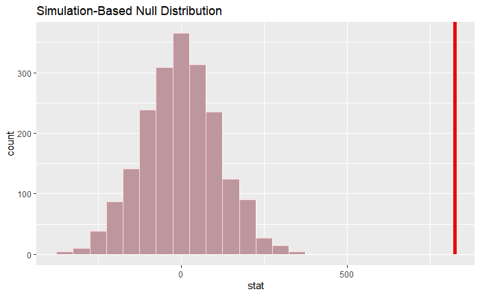

```r
null_distribution <- let_prices %>%
  specify(price ~ location) %>%
  hypothesise(null = "independence") %>%
  generate(2000, type = "permute") %>%
  calculate(stat = "diff in means",
            order = c("florence", "corfu"))

visualise(null_distribution) +
  shade_p_value(observed_stat$price_diff, "less")
```

## Calculate p value

```r
p_value <- null_distribution %>%
  get_p_value(
    obs_stat = observed_stat$price_diff,
    direction = "less"
  ) %>%
  pull()

format.pval(p_value, )
```

```
[1] "1"
```

## Conclude

p approaches 1, therefore we can not reject our null hypothesis: lets in Corfu are most likely not more expensive than in Florence.

# 2 Sample Paired

Paired means a row in Sample A relates to a row in Sample B

Amazon Waterstones The Catcher in the Rye The Catcher in the Rye

Before Treatment After Treatment Test Subject: A Test Subject: A

We’re going to consider textbook prices sold from two sellers. One at a campus bookshop, one at Amazon. We want to know:

> Is there a significant difference between the prices for new texts offered by the campus bookshop vs the prices for the same texts on Amazon

Let’s assume the opposite. That there is no difference between the prices of texts from the two sellers. We’d expect mean_campus - mean_amazon = 0, forming our null hypothesis.

| year | term | subject | subject_abbr | course | course_num | course_numeric | seminar | ind_study | apprenticeship | internship | honors_contracts | laboratory | special_topic | textbook_isbn | bookstore_new | bookstore_used | amazon_new | amazon_used | notes |
| --- | --- | --- | --- | --- | --- | --- | --- | --- | --- | --- | --- | --- | --- | --- | --- | --- | --- | --- | --- |
| 2018 | Fall | American Indian Studies | AM IND | Introduction to American Indian Studies | M10 | 10 | FALSE | FALSE | FALSE | FALSE | FALSE | FALSE | FALSE | 9.781138e+12 | 47.97 | 44.97 | 47.45 | 51.20 | NA |
| 2018 | Fall | Anthropology | ANTHRO | Archaeology: Introduction | 2 | 2 | FALSE | FALSE | FALSE | FALSE | FALSE | FALSE | FALSE | 9.780308e+12 | 14.26 | 10.96 | 13.55 | 7.10 | NA |
| 2018 | Fall | Art | NA | New Genres | 11D | 11 | FALSE | FALSE | FALSE | FALSE | FALSE | FALSE | FALSE | NA | NA | NA | NA | NA | NA |
| 2018 | Fall | Arts and Architecture | ART&ARC | Arts Encounters: Exploring Arts Literacy in 21st Century | 10 | 10 | FALSE | FALSE | FALSE | FALSE | FALSE | FALSE | FALSE | 9.780980e+12 | 13.50 | 11.00 | 12.53 | NA | NA |
| 2018 | Fall | Asian | NA | Introduction to Buddhism | M60W | 60 | FALSE | FALSE | FALSE | FALSE | FALSE | FALSE | FALSE | 9.780200e+12 | 49.26 | 43.26 | 54.95 | 24.83 | NA |
| 2018 | Fall | Astronomy | ASTR | Black Holes and Cosmic Catastrophes | 4 | 4 | FALSE | FALSE | FALSE | FALSE | FALSE | FALSE | FALSE | 9.780134e+12 | 119.97 | 67.00 | 124.80 | 47.75 | NA |
| 2018 | Fall | Biomedical Research | BMD RES | Biomedical Research: Concepts and Strategies | 5HA | 5 | FALSE | FALSE | FALSE | FALSE | FALSE | FALSE | FALSE | NA | NA | NA | NA | NA | NA |
| 2018 | Fall | Chemistry and Biochemistry | CHEM | Atomic and Molecular Structure, Equilibria, Acids, and Bases | 14A | 14 | FALSE | FALSE | FALSE | FALSE | FALSE | FALSE | FALSE | 9.781319e+12 | 188.10 | 149.00 | NA | NA | NA |
| 2018 | Fall | Chemistry and Biochemistry | CHEM | Thermodynamics, Electrochemistry, Kinetics, and Organic Chemistry | 14B | 14 | FALSE | FALSE | FALSE | FALSE | FALSE | FALSE | FALSE | 9.781319e+12 | 215.75 | 162.00 | NA | 90.00 | New version only from resellers |
| 2018 | Fall | Chicana and Chicano Studies | CHICANO | Elementary Nahuatl | M5A | 5 | FALSE | FALSE | FALSE | FALSE | FALSE | FALSE | FALSE | NA | NA | NA | NA | NA | NA |

## Wrangle data

Extra step in the process for paired samples :

Do a calculation that represents the question to allow the row to contain just one value of interest, allowing you to treat it the same as a one sample mean test.

In this case, doing `bookstore_new - amazon_new` calculates the difference we require, and we can just look at the mean of this one value, bringing a row of 2 observations down to a row of 1 observation.

| textbook_isbn | bookstore_new | amazon_new | price_diff |
| --- | --- | --- | --- |
| 9.781138e+12 | 47.97 | 47.45 | 0.52 |
| 9.780308e+12 | 14.26 | 13.55 | 0.71 |
| NA | NA | NA | NA |
| 9.780980e+12 | 13.50 | 12.53 | 0.97 |
| 9.780200e+12 | 49.26 | 54.95 | -5.69 |
| 9.780134e+12 | 119.97 | 124.80 | -4.83 |
| NA | NA | NA | NA |
| 9.781319e+12 | 188.10 | NA | NA |
| 9.781319e+12 | 215.75 | NA | NA |
| NA | NA | NA | NA |

[output cut: 191 more lines]

## Define test and alpha

H0 = mean_price_diff = 0 HA = mean_price_diff != 0 (Two-tailed test)

alpha = 0.05

## Calculate observed stat

| mean_price_diff |
| --- |
| 3.583235 |

## Generate null distribution and visualise

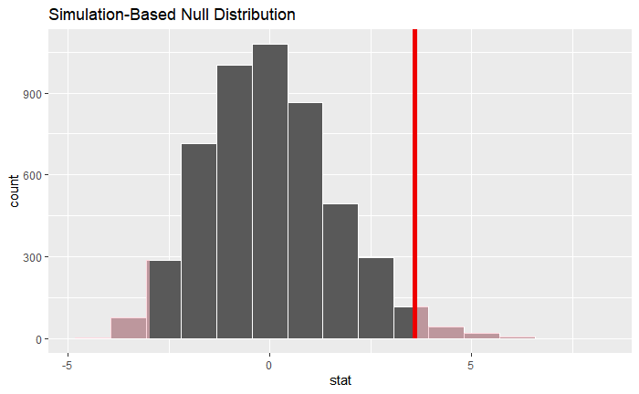

## Calculate p-value

| p_value |
| --- |
| 0.0384 |

## Conclusion

p value = 0.038 alpha = 0.05

p_value < alpha, therefore we can reject our null hypothesis and conclude it is likely there is a significant difference between campus book prices and those on Amazon.